# 3-SA-meta-analyis.Rmd

Seth Green

08 July, 2023

### Overview

This document will work through our results, and its aim is to both reflect the pre-analyis plan as it was written in 2018 and the most up-to-date version of the text. Everything in our pre-analysis plan will be included in either the main results section or an appendix, but not necessarily in the order it was drafted up.

This document will precede chunks with quotes prepended either a “*paper*” or a “*pap*” to denote whether the text is from the paper or the pre-analysis plan.

## Results

### Overall results and publication bias

*paper*: “Our random effects meta-analysis of all primary prevention strategies from 1985 to 2018 reveals an overall effect size, across all interventions on all kinds of outcomes, of $\Delta$ = 0.281 (se = 0.024). This effect is statistically significant at p $<$ 0.0001.”

```r
dat %>% map_robust()
```

```
## # A tibble: 1 × 3
##    beta    se pval
##   <dbl> <dbl> <chr>
## 1 0.281 0.024 < 0.0001
```

```r
# more verbose version of
robust(x = rma(yi = d, vi = var_d, data = dat),
       cluster = dat$unique_study_id)
```

```
##
## Random-Effects Model (k = 500; tau^2 estimator: REML)
##
## tau^2 (estimated amount of total heterogeneity): 0.1675 (SE = 0.0131)
## tau (square root of estimated tau^2 value):      0.4092
## I^2 (total heterogeneity / total variability):   91.68%
## H^2 (total variability / sampling variability):  12.01
##
## Test for Heterogeneity:
## Q(df = 499) = 5798.7124, p-val < .0001
##
## Number of estimates:   500
## Number of clusters:    304
## Estimates per cluster: 1-6 (mean: 1.64, median: 1)
##
## Model Results:
##
## estimate      se¹     tval¹   df¹    pval¹   ci.lb¹   ci.ub¹
##   0.2811  0.0244   11.5235   303   <.0001   0.2331   0.3291   ***
##
## ---
## Signif. codes:  0 '***' 0.001 '**' 0.01 '*' 0.05 '.' 0.1 ' ' 1
##
## 1) results based on cluster-robust inference (var-cov estimator: CR1,
##    approx t-test and confidence interval, df: residual method)
```

# Figure 1

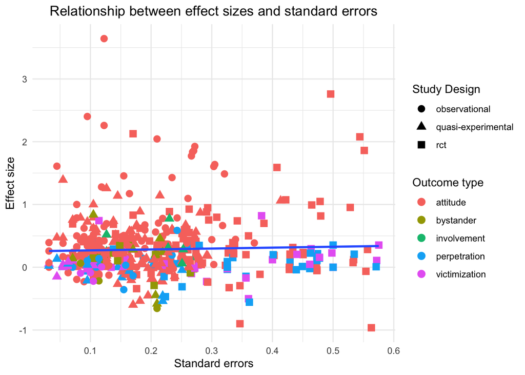

```r
dat %>% ggplot(mapping = aes(y = d,
                             x = se_d)) +
  geom_point(aes(color = behavior_type,
             shape = study_design),
             size = 3) +
  stat_smooth(method = 'lm', se = F) +
  ggtitle("Relationship between effect sizes and standard errors") +
  labs(x = "Standard errors",
       y = "Effect size",
       color = "Outcome type",
       shape = "Study Design") +
  theme_minimal() +
  theme(plot.title = element_text(hjust = 0.5))
```

“First, we do not observe a significant relationship between effect sizes and standard errors: $\beta$ = 0.145 (se = 0.176), p = 0.411”

```r
sum_lm(dat, d, se_d, coefs_only = T)
```

```
##             Estimate Std. Error t value Pr(>|t|)
## (Intercept)  0.25429    0.04258 5.97175   0.0000
## se_d         0.14494    0.17634 0.82195   0.4115
```

```r
# Ns
dat %>%
  group_by(study_design) %>%
  study_count()
```

```
## # A tibble: 3 × 2
##   study_design       `N (studies)`
##   <chr>                      <int>
## 1 observational                 99
## 2 quasi-experimental           104
## 3 rct                          102
```

```r
# effect sizes
dat %>%
  split(.$study_design) %>%
  map(.f = ~sum_lm(y = d, x = se_d, dat = .)) # can just do `map(.f = ~sum_lm())
```

```
## $observational
##             Estimate Std. Error t value Pr(>|t|)
## (Intercept)  0.09226    0.10660 0.86543  0.38826
## se_d         2.22736    0.63993 3.48063  0.00066
##
## $`quasi-experimental`
##             Estimate Std. Error  t value Pr(>|t|)
## (Intercept)  0.24252    0.06897  3.51654  0.00056
## se_d        -0.20125    0.39293 -0.51218  0.60917
##
## $rct
##             Estimate Std. Error t value Pr(>|t|)
## (Intercept)  0.18346    0.08467 2.16679  0.03158
## se_d         0.20773    0.25571 0.81239  0.41765
```

```r
dat %>%
  group_by(published_unpublished) %>%
    study_count()
```

```
## # A tibble: 2 × 2
##   published_unpublished `N (studies)`
##   <chr>                         <int>
## 1 published                       193
## 2 unpublished                     111
```

```r
# sanity check
length(unique(dat$unique_study_id)) == 186 + 118
```

```
## [1] TRUE
```

```r
dat %>% sum_lm(d, published_unpublished)
```

```
##                                  Estimate Std. Error  t value Pr(>|t|)
## (Intercept)                       0.30381    0.02689 11.29941  0.00000
## published_unpublishedunpublished -0.05012    0.04350 -1.15206  0.24985
```

```r
# what are the quantiles
dat %>% group_by(quantile_var) %>%
  summarise(min_n = min(n_t_post + n_c_post),
            max_n = max(n_t_post + n_c_post))
```

```
## # A tibble: 5 × 3
##   quantile_var min_n max_n
##          <dbl> <dbl> <dbl>
## 1            1    20    72
## 2            2    73   142
## 3            3   143   264
## 4            4   272   474
## 5            5   476  7010
```

```r
dat %>%
  split(.$quantile_var) %>% map(.f = map_robust)
```

```
## $`1`
## # A tibble: 1 × 3
##    beta    se pval
##   <dbl> <dbl> <chr>
## 1 0.302 0.043 < 0.0001
##
## $`2`
## # A tibble: 1 × 3
##    beta    se pval
##   <dbl> <dbl> <chr>
## 1  0.25 0.057 < 0.0001
##
## $`3`
## # A tibble: 1 × 3
##    beta    se pval
##   <dbl> <dbl> <chr>
## 1 0.275 0.041 < 0.0001
##
## $`4`
## # A tibble: 1 × 3
##    beta    se pval
##   <dbl> <dbl> <chr>
## 1 0.296 0.044 < 0.0001
##
## $`5`
## # A tibble: 1 × 3
##    beta    se   pval
##   <dbl> <dbl>  <dbl>
## 1 0.275 0.073 0.0004
```

```r
## well it's not *nothing*...but it's pretty small
dat %>% sum_lm(y = d, x = quantile_var) # it's basically nothing
```

```
##              Estimate Std. Error  t value Pr(>|t|)
## (Intercept)   0.29354    0.04974  5.90104  0.00000
## quantile_var -0.00295    0.01497 -0.19709  0.84384
```

```r
dat %>% sum_lm(y = d, x = delay)
```

```
##             Estimate Std. Error  t value Pr(>|t|)
## (Intercept)  0.30196    0.02387 12.65071  0.00000
## delay       -0.00023    0.00014 -1.55338  0.12097
```

```r
# TODO: remove or move to appendix
# how many delayed outcomes
table(dat$yes_delay)
```

```
##
## FALSE  TRUE
##   193   307
```

```r
dat %>% sum_lm(d, yes_delay)
```

```
##               Estimate Std. Error  t value Pr(>|t|)
## (Intercept)    0.40021    0.03342 11.97540  0.00000
## yes_delayTRUE -0.18818    0.04265 -4.41232  0.00001
```

```r
## What's the longest attitude/behavior delay measurement?
dat %>%
  group_by(scale_type) %>%
  summarize(max_delay = max(delay))
```

```
## # A tibble: 2 × 2
##   scale_type max_delay
##   <fct>          <dbl>
## 1 attitudes        819
## 2 behavior        1461
```

However, when pooling all effects, we observe that results vary both significantly and substantively by study design.

```r
# count Ns (again, just for convenience of writing)
dat %>% group_by(study_design) %>%
  study_count()
```

```
## # A tibble: 3 × 2
##   study_design       `N (studies)`
##   <chr>                      <int>
## 1 observational                 99
## 2 quasi-experimental           104
## 3 rct                          102
```

```r
# check overall effect sizes
dat %>%
  split(.$study_design) %>%
  map(.f = map_robust)
```

```
## $observational
## # A tibble: 1 × 3
##    beta    se pval
##   <dbl> <dbl> <chr>
## 1 0.412 0.058 < 0.0001
##
## $`quasi-experimental`
## # A tibble: 1 × 3
##    beta    se pval
##   <dbl> <dbl> <chr>
## 1 0.213  0.03 < 0.0001
##
## $rct
## # A tibble: 1 × 3
##    beta    se pval
##   <dbl> <dbl> <chr>
## 1  0.24 0.033 < 0.0001
```

```r
#TODO: can we reshape these two objects to be one table and then make them a latex table?
# and then eventually a function which just takes dat as its input?
```

# Attitudinal Change exceeds behavioral change in every category of study

In our sample, attitudinal outcomes outnumber behavioral outcomes by 355 to 145. 207 studies measure attitudes only, 36 measure only behaviors, while 61 measure both.

```r
table(dat$scale_type)
```

```
##
## attitudes  behavior
##       355       145
```

```r
dat %>%
  group_by(has_both) %>%
  study_count()
```

```
## # A tibble: 3 × 2
##   has_both  `N (studies)`
##   <chr>             <int>
## 1 attitudes           207
## 2 behavior             36
## 3 both                 61
```

```r
# sanity check
length(unique(dat$unique_study_id)) == 207 + 36 + 61 # true
```

```
## [1] TRUE
```

Behavioral measurement has become more common over time, particularly from 2010 onward.

```r
range(dat$year)
```

```
## [1] 1986 2018
```

```r
# how many studies in each decade
dat %>% group_by(decade) %>% study_count()
```

```
## # A tibble: 4 × 2
##   decade `N (studies)`
##   <fct>          <int>
## 1 1980s              7
## 2 1990s             94
## 3 2000s             61
## 4 2010s            142
```

```r
tab <- merge(x = dat %>% group_by(decade) %>% study_count(),
             y = dat %>% group_by(decade, scale_type) %>% summarise(n = n()))
# print tab
tab
```

```
##   decade N (studies) scale_type   n
## 1  1980s           7  attitudes   7
## 2  1990s          94  attitudes 135
## 3  1990s          94   behavior  29
## 4  2000s          61  attitudes  70
## 5  2000s          61   behavior  19
## 6  2010s         142  attitudes 143
## 7  2010s         142   behavior  97
```

```r
#reshape and make latex table
tab %>%
  pivot_wider(names_from = scale_type, values_from = n) %>%
  mutate(ratio = attitudes/behavior) %>%
  knitr::kable(format = 'latex')
```

```r
# what was the earliest study to measure behavior as we conceive it?
dat %>% filter(scale_type == 'behavior') %>%
  arrange(year) %>%
  select(author, year, paper_title) %>% head()
```

```
## # A tibble: 6 × 3
##   author   year paper_title
##   <chr>   <int> <chr>
## 1 gilbert  1991 Changing the Sexual Agressive Suportive Attitudes of Men: A Psy…
## 2 gibson   1991 An intervention designed to modify attitudes toward acquaintanc…
## 3 gibson   1991 An intervention designed to modify attitudes toward acquaintanc…
## 4 gibson   1991 An intervention designed to modify attitudes toward acquaintanc…
## 5 gibson   1991 An intervention designed to modify attitudes toward acquaintanc…
## 6 nagler   1993 Effect of an acquaintance rape prevention program on rape attit…
```

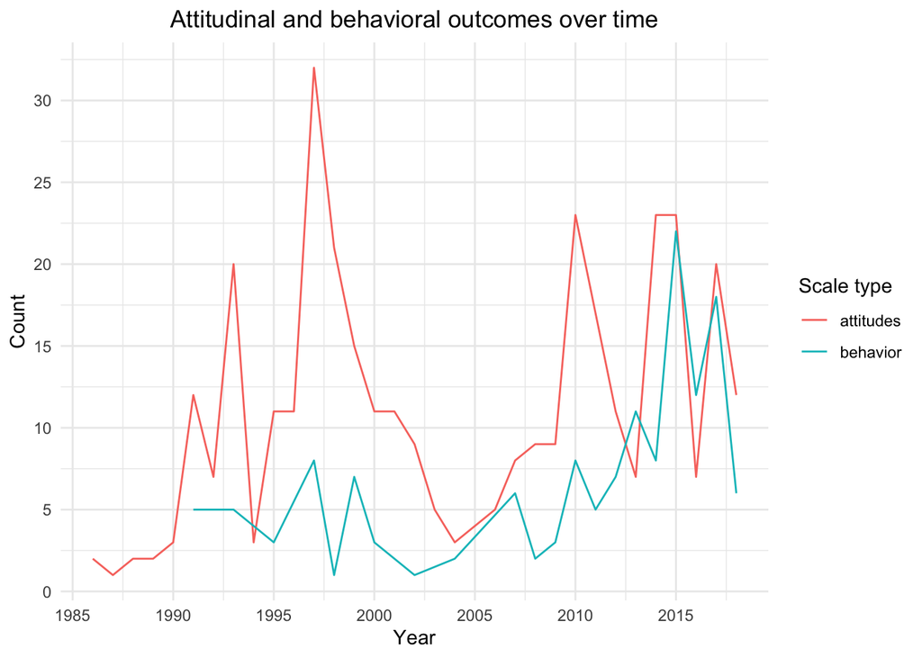

```r
# optional histogram
dat %>% ggplot(aes(x = year, color = scale_type)) +
  geom_line(stat = 'count') +
  labs(x = "Year",
       y = "Count",
       color = "Scale type",
       title = "Attitudinal and behavioral outcomes over time") +
  # scale_x_date(date_breaks = "2 years") +
  scale_x_continuous(n.breaks = 10) +
  scale_y_continuous(n.breaks = 10) +
  theme_minimal() +
  theme(plot.title = element_text(hjust = 0.5))
```

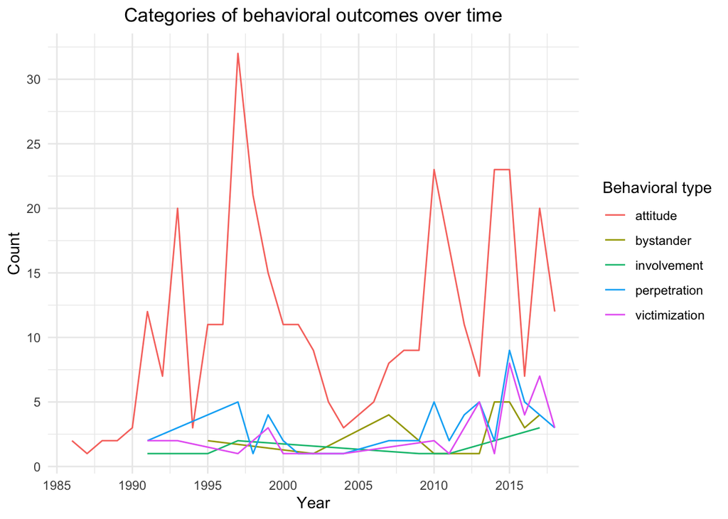

```r
## what if we just do this for behaviors?
dat %>%
  ggplot(aes(x = year, color = behavior_type)) +
  geom_line(stat = 'count') +
  labs(x = "Year",
       y = "Count",
       color = "Behavioral type",
       title = "Categories of behavioral outcomes over time") +
  # scale_x_date(date_breaks = "2 years") +
  scale_x_continuous(n.breaks = 10) +
  scale_y_continuous(n.breaks = 10) +
  theme_minimal() +
  theme(plot.title = element_text(hjust = 0.5))
```

```r
# can also filter out attitudes if we want (filter(scale_type == 'attitudes'))
```

Overall, behaviors are much more resistant to change than attitudes. The overall effect size for attitudes is $\Delta$ = 0.367 (se = .03), p < 0.0001; while the overall effect size for behaviors is $\Delta$ = 0.072 (se = 0.022) p = 0.0013. While this is still a statistically significant result, it does not meet the conventional threshold for a ‘small’ effect size.

```r
dat %>%
  split(.$scale_type) %>%
  map(.f = map_robust)
```

```
## $attitudes
## # A tibble: 1 × 3
##    beta    se pval
##   <dbl> <dbl> <chr>
## 1 0.367  0.03 < 0.0001
##
## $behavior
## # A tibble: 1 × 3
##    beta    se   pval
##   <dbl> <dbl>  <dbl>
## 1 0.072 0.022 0.0013
```

This discrepancy is particularly pronounced in observational research, where attitudinal outcomes are about 18 times larger than behavioral responses; but the discrepancy is substantial across every category of study design. However, it is notable that the largest behavioral effects are found within randomized studies, i.e. the most rigorous designs.

```r
# first, Ns

dat %>%
  group_by(scale_type, study_design) %>%
  study_count() %>%
  kable('latex')
```

```r
# then effect sizes
dat %>%
  split(list(.$scale_type, .$study_design)) %>%
  map(.f = map_robust)
```

```
## $attitudes.observational
## # A tibble: 1 × 3
##    beta    se pval
##   <dbl> <dbl> <chr>
## 1 0.505 0.067 < 0.0001
##
## $behavior.observational
## # A tibble: 1 × 3
##    beta    se  pval
##   <dbl> <dbl> <dbl>
## 1 0.028 0.032 0.394
##
## $`attitudes.quasi-experimental`
## # A tibble: 1 × 3
##    beta    se pval
##   <dbl> <dbl> <chr>
## 1 0.278 0.036 < 0.0001
##
## $`behavior.quasi-experimental`
## # A tibble: 1 × 3
##    beta    se   pval
##   <dbl> <dbl>  <dbl>
## 1 0.075 0.034 0.0331
##
## $attitudes.rct
## # A tibble: 1 × 3
##    beta    se pval
##   <dbl> <dbl> <chr>
## 1 0.319 0.043 < 0.0001
##
## $behavior.rct
## # A tibble: 1 × 3
##    beta    se   pval
##   <dbl> <dbl>  <dbl>
## 1 0.107 0.045 0.0213
```

In our dataset, behavioral outcomes can be classified as victimization, perpetration, bystander (intervening in a situation where perpetration is perceived to be a risk), and involvement (for example, signing up to be part of a rape awareness group on campus).

```r
#Ns
dat %>%
  group_by(behavior_type) %>%
  summarize('N (studies)' = n_distinct(unique_study_id)) %>%
  kable('latex')
```

```r
dat %>%
  split(.$behavior_type) %>%
  map(.f = map_robust)
```

```
## $attitude
## # A tibble: 1 × 3
##    beta    se pval
##   <dbl> <dbl> <chr>
## 1 0.367  0.03 < 0.0001
##
## $bystander
## # A tibble: 1 × 3
##    beta    se   pval
##   <dbl> <dbl>  <dbl>
## 1 0.129 0.059 0.0394
##
## $involvement
## # A tibble: 1 × 3
##    beta    se  pval
##   <dbl> <dbl> <dbl>
## 1 0.262 0.086 0.016
##
## $perpetration
## # A tibble: 1 × 3
##    beta    se  pval
##   <dbl> <dbl> <dbl>
## 1 0.035  0.02 0.093
##
## $victimization
## # A tibble: 1 × 3
##    beta    se  pval
##   <dbl> <dbl> <dbl>
## 1 0.045 0.029 0.122
```

Here we see that primary prevention interventions do not, on average, meaningfully reduce victimization or perpetration. This, we think, is the key finding of this meta-analysis. % if I were reading this right now I’d want more zoom in on how different *categories* of intervention reduce victimization & perpetration.

### RCT perpetration

```r
dat %>%
  filter(study_design == 'rct' & behavior_type == 'perpetration') %>%
  map_robust()
```

```
## # A tibble: 1 × 3
##    beta    se  pval
##   <dbl> <dbl> <dbl>
## 1 0.081 0.062 0.198
```

# correlation between attitudes and behavior

Another way to assess the discrepancy between attitudes and behaviors is to focus on the 61 studies that measure both and look at the association between the two categories.

```r
dat_has_both <- dat %>% filter(has_both == 'both')
dat_has_both %>% study_count()
```

```
## # A tibble: 1 × 1
##   `N (studies)`
##           <int>
## 1            61
```

In this subset of studies, the pooled attitudinal effect is $\Delta$ = 0.278 (se = .036), p < .0001, while the pooled behavioral outcome is $\Delta$ = 0.081 (se = .03), p = .009. In other words, the attitudinal effects are slightly lower than the overall attitude effect of 0.367, while the behavioral effects are slightly larger than the overall behavioral effect of 0.072.

```r
dat_has_both %>% split(.$scale_type) %>% map(.f = map_robust)
```

```
## $attitudes
## # A tibble: 1 × 3
##    beta    se pval
##   <dbl> <dbl> <chr>
## 1 0.278 0.036 < 0.0001
##
## $behavior
## # A tibble: 1 × 3
##    beta    se  pval
##   <dbl> <dbl> <dbl>
## 1 0.081  0.03 0.009
```

A key question for this literature is: when attitudes change, do behaviors change with them? Unfortunately, in the studies that measure change across both categories, we find a small, statistically insignificant correlation of $\rho$ (59) = 0.141, p = 0.279.

```r
## TODO John-Henry: is there a way to get the behavior_type that corresponds
# to the behavior (rather than 'attitude') into this reshaped dataset,
# such that we could:
# A) subsequently filter it down just to look at each kind behavior
# B) color code the scatterplot
has_both_means <- dat_has_both %>%
  group_by(unique_study_id, scale_type) %>%
  mutate(mean_d = mean(d),
         mean_var_d = mean(var_d),
         mean_se_d = mean(se_d)) %>%
  select(author, year, paper_title, unique_study_id, intervention_name,
         study_design, mean_d, mean_var_d, mean_se_d,
         ra, labels, scale_type, decade, behavior_type) %>%
  slice(1)

has_both_reshaped <- has_both_means %>%
  pivot_wider(
    id_cols = c(author, year, paper_title, unique_study_id,
                intervention_name,
                unique_study_id, study_design, ra, labels, decade),
    names_from = c(scale_type),
    values_from = c(mean_d, mean_var_d, mean_se_d))

cor.test(x = has_both_reshaped$mean_d_attitudes,
         y = has_both_reshaped$mean_d_behavior)
```

```
##
##  Pearson's product-moment correlation
##
## data:  has_both_reshaped$mean_d_attitudes and has_both_reshaped$mean_d_behavior
## t = 1.0937, df = 59, p-value = 0.2785
## alternative hypothesis: true correlation is not equal to 0
## 95 percent confidence interval:
##  -0.1149387  0.3793181
## sample estimates:
##       cor
## 0.1409621
```

```r
# RCTs only?
rcts_both <- has_both_reshaped %>% filter(study_design == 'rct')
cor.test(x = rcts_both$mean_d_attitudes,
         y = rcts_both$mean_d_behavior)
```

```
##
##  Pearson's product-moment correlation
##
## data:  rcts_both$mean_d_attitudes and rcts_both$mean_d_behavior
## t = 0.73639, df = 25, p-value = 0.4683
## alternative hypothesis: true correlation is not equal to 0
## 95 percent confidence interval:
##  -0.2480422  0.4981379
## sample estimates:
##       cor
## 0.1457059
```

```r
#perp and vict only?
perp_and_vict_both <- has_both_means %>%
  group_by(unique_study_id) %>%
  filter(if_else(any(behavior_type %in% c('involvement', 'bystander')), F, T)) %>%
   pivot_wider(
    id_cols = c(author, year, paper_title, unique_study_id,
                intervention_name,
                unique_study_id, study_design, ra, labels, decade),
    names_from = c(scale_type),
    values_from = c(mean_d, mean_var_d, mean_se_d))

cor.test(perp_and_vict_both$mean_d_attitudes,
         perp_and_vict_both$mean_d_behavior)
```

```
##
##  Pearson's product-moment correlation
##
## data:  perp_and_vict_both$mean_d_attitudes and perp_and_vict_both$mean_d_behavior
## t = 1.0014, df = 42, p-value = 0.3224
## alternative hypothesis: true correlation is not equal to 0
## 95 percent confidence interval:
##  -0.1510213  0.4300879
## sample estimates:
##       cor
## 0.1527057
```

```r
# finally, perp and vict only in RCTs only

perp_and_vict_rcts <- has_both_means %>%
  group_by(unique_study_id) %>%
  filter(if_else(any(behavior_type %in% c('involvement', 'bystander')), F, T)) %>%
  filter(study_design == 'rct') %>%
   pivot_wider(
    id_cols = c(author, year, paper_title, unique_study_id,
                intervention_name,
                unique_study_id, study_design, ra, labels, decade),
    names_from = c(scale_type),
    values_from = c(mean_d, mean_var_d, mean_se_d))

cor.test(perp_and_vict_rcts$mean_d_attitudes,
         perp_and_vict_rcts$mean_d_behavior)
```

```
##
##  Pearson's product-moment correlation
##
## data:  perp_and_vict_rcts$mean_d_attitudes and perp_and_vict_rcts$mean_d_behavior
## t = 0.53912, df = 19, p-value = 0.5961
## alternative hypothesis: true correlation is not equal to 0
## 95 percent confidence interval:
##  -0.3262256  0.5265339
## sample estimates:
##       cor
## 0.1227473
```

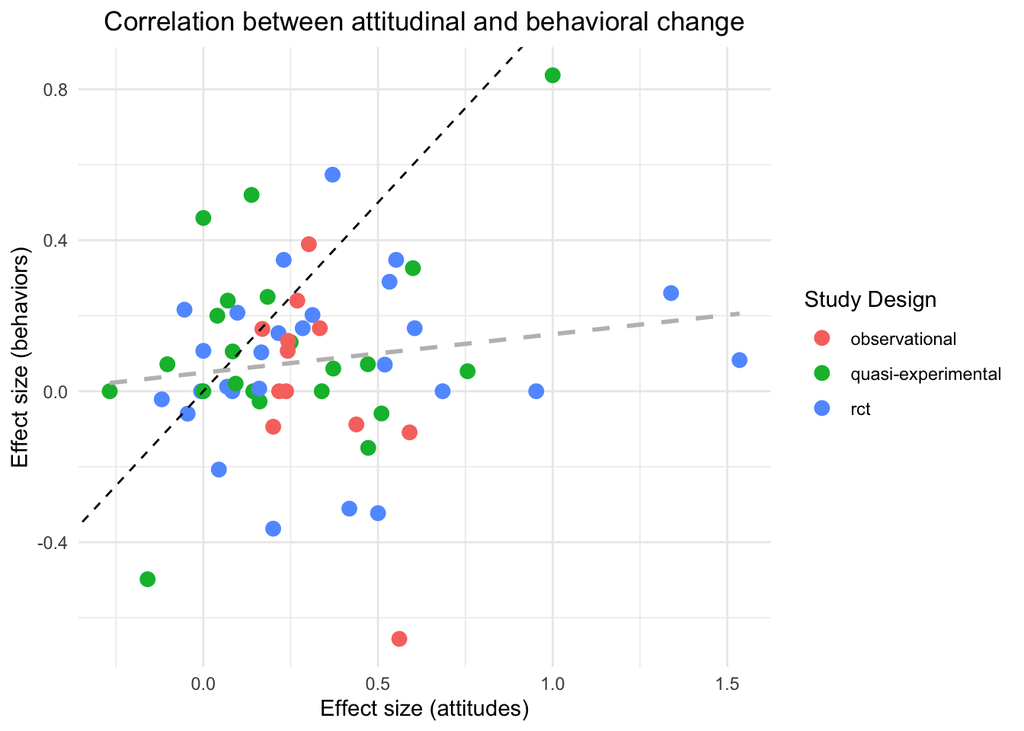

```r
# ok now scatterplot

has_both_reshaped %>%
  ggplot(mapping = aes(x = mean_d_attitudes,
                       y = mean_d_behavior)) +
  geom_point(aes(color = study_design),
             size = 3) +
  geom_abline(slope = 1, lty = 'dashed') +
  stat_smooth(lty = "dashed",
              method = "lm",
              se = FALSE,
              color = 'grey') +
  labs(title = "Correlation between attitudinal and behavioral change",
       x = "Effect size (attitudes)",
       y = "Effect size (behaviors)",
       color = "Study Design") +
#  scale_color_discrete(labels = c("pre-post" = "observational")) +
  guides(color = guide_legend(title = "Study Design")) +
  theme_minimal() +
  theme(plot.title = element_text(hjust = 0.5))
```

In sum, while attitudes towards rape myths appear to malleable, the problem of rape itself is much more resistant to change.